# Risk Factor Analysis

## Outcome Variable

**Outcome Variable:** ever_co

## Predictor Variables

**Intervention Variable:** birthwt

**Adjustment Set:**

- arm
- sex
- W_mage
- meducyrs
- feducyrs
- vagbrth
- single
- brthmon
- W_parity
- delta_W_mage
- delta_meducyrs
- delta_feducyrs
- delta_vagbrth
- delta_single
- delta_brthmon
- delta_W_parity

## Stratifying Variables

The analysis was stratified on these variable(s):

- agecat
- studyid
- country

## Data Summary

| agecat | studyid | country | birthwt | ever_co | n_cell | n |
| --- | --- | --- | --- | --- | --- | --- |
| 0-24 months | ki0047075b-MAL-ED | BANGLADESH | Normal or high birthweight | 0 | 183 | 257 |
| 0-24 months | ki0047075b-MAL-ED | BANGLADESH | Normal or high birthweight | 1 | 21 | 257 |
| 0-24 months | ki0047075b-MAL-ED | BANGLADESH | Low birth weight | 0 | 37 | 257 |
| 0-24 months | ki0047075b-MAL-ED | BANGLADESH | Low birth weight | 1 | 16 | 257 |
| 0-24 months | ki0047075b-MAL-ED | BRAZIL | Normal or high birthweight | 0 | 219 | 233 |
| 0-24 months | ki0047075b-MAL-ED | BRAZIL | Normal or high birthweight | 1 | 2 | 233 |
| 0-24 months | ki0047075b-MAL-ED | BRAZIL | Low birth weight | 0 | 12 | 233 |
| 0-24 months | ki0047075b-MAL-ED | BRAZIL | Low birth weight | 1 | 0 | 233 |
| 0-24 months | ki0047075b-MAL-ED | INDIA | Normal or high birthweight | 0 | 168 | 243 |
| 0-24 months | ki0047075b-MAL-ED | INDIA | Normal or high birthweight | 1 | 37 | 243 |
| 0-24 months | ki0047075b-MAL-ED | INDIA | Low birth weight | 0 | 24 | 243 |
| 0-24 months | ki0047075b-MAL-ED | INDIA | Low birth weight | 1 | 14 | 243 |
| 0-24 months | ki0047075b-MAL-ED | NEPAL | Normal or high birthweight | 0 | 200 | 233 |
| 0-24 months | ki0047075b-MAL-ED | NEPAL | Normal or high birthweight | 1 | 12 | 233 |
| 0-24 months | ki0047075b-MAL-ED | NEPAL | Low birth weight | 0 | 15 | 233 |
| 0-24 months | ki0047075b-MAL-ED | NEPAL | Low birth weight | 1 | 6 | 233 |
| 0-24 months | ki0047075b-MAL-ED | PERU | Normal or high birthweight | 0 | 274 | 299 |
| 0-24 months | ki0047075b-MAL-ED | PERU | Normal or high birthweight | 1 | 7 | 299 |
| 0-24 months | ki0047075b-MAL-ED | PERU | Low birth weight | 0 | 13 | 299 |
| 0-24 months | ki0047075b-MAL-ED | PERU | Low birth weight | 1 | 5 | 299 |
| 0-24 months | ki0047075b-MAL-ED | SOUTH AFRICA | Normal or high birthweight | 0 | 275 | 312 |
| 0-24 months | ki0047075b-MAL-ED | SOUTH AFRICA | Normal or high birthweight | 1 | 15 | 312 |
| 0-24 months | ki0047075b-MAL-ED | SOUTH AFRICA | Low birth weight | 0 | 15 | 312 |
| 0-24 months | ki0047075b-MAL-ED | SOUTH AFRICA | Low birth weight | 1 | 7 | 312 |
| 0-24 months | ki0047075b-MAL-ED | TANZANIA, UNITED REPUBLIC OF | Normal or high birthweight | 0 | 120 | 135 |
| 0-24 months | ki0047075b-MAL-ED | TANZANIA, UNITED REPUBLIC OF | Normal or high birthweight | 1 | 8 | 135 |
| 0-24 months | ki0047075b-MAL-ED | TANZANIA, UNITED REPUBLIC OF | Low birth weight | 0 | 6 | 135 |
| 0-24 months | ki0047075b-MAL-ED | TANZANIA, UNITED REPUBLIC OF | Low birth weight | 1 | 1 | 135 |
| 0-24 months | ki1000108-CMC-V-BCS-2002 | INDIA | Normal or high birthweight | 0 | 271 | 373 |
| 0-24 months | ki1000108-CMC-V-BCS-2002 | INDIA | Normal or high birthweight | 1 | 59 | 373 |

[output cut: 318 more lines]

The following strata were considered:

- agecat: 0-24 months, studyid: ki0047075b-MAL-ED, country: BANGLADESH
- agecat: 0-24 months, studyid: ki0047075b-MAL-ED, country: BRAZIL
- agecat: 0-24 months, studyid: ki0047075b-MAL-ED, country: INDIA
- agecat: 0-24 months, studyid: ki0047075b-MAL-ED, country: NEPAL
- agecat: 0-24 months, studyid: ki0047075b-MAL-ED, country: PERU
- agecat: 0-24 months, studyid: ki0047075b-MAL-ED, country: SOUTH AFRICA
- agecat: 0-24 months, studyid: ki0047075b-MAL-ED, country: TANZANIA, UNITED REPUBLIC OF
- agecat: 0-24 months, studyid: ki1000108-CMC-V-BCS-2002, country: INDIA
- agecat: 0-24 months, studyid: ki1000108-IRC, country: INDIA
- agecat: 0-24 months, studyid: ki1000109-EE, country: PAKISTAN
- agecat: 0-24 months, studyid: ki1000109-ResPak, country: PAKISTAN
- agecat: 0-24 months, studyid: ki1000304b-SAS-CompFeed, country: INDIA
- agecat: 0-24 months, studyid: ki1017093-NIH-Birth, country: BANGLADESH
- agecat: 0-24 months, studyid: ki1017093b-PROVIDE, country: BANGLADESH
- agecat: 0-24 months, studyid: ki1017093c-NIH-Crypto, country: BANGLADESH
- agecat: 0-24 months, studyid: ki1066203-TanzaniaChild2, country: TANZANIA, UNITED REPUBLIC OF
- agecat: 0-24 months, studyid: ki1101329-Keneba, country: GAMBIA
- agecat: 0-24 months, studyid: ki1114097-CMIN, country: BANGLADESH
- agecat: 0-24 months, studyid: ki1114097-CMIN, country: BRAZIL
- agecat: 0-24 months, studyid: ki1114097-CMIN, country: GUINEA-BISSAU
- agecat: 0-24 months, studyid: ki1114097-CMIN, country: PERU
- agecat: 0-24 months, studyid: ki1114097-CONTENT, country: PERU
- agecat: 0-24 months, studyid: ki1119695-PROBIT, country: BELARUS
- agecat: 0-24 months, studyid: ki1126311-ZVITAMBO, country: ZIMBABWE
- agecat: 0-24 months, studyid: ki1135781-COHORTS, country: GUATEMALA
- agecat: 0-24 months, studyid: ki1135781-COHORTS, country: INDIA
- agecat: 0-24 months, studyid: ki1135781-COHORTS, country: PHILIPPINES
- agecat: 0-24 months, studyid: kiGH5241-JiVitA-3, country: BANGLADESH
- agecat: 0-24 months, studyid: kiGH5241-JiVitA-4, country: BANGLADESH
- agecat: 0-6 months, studyid: ki0047075b-MAL-ED, country: BANGLADESH
- agecat: 0-6 months, studyid: ki0047075b-MAL-ED, country: BRAZIL
- agecat: 0-6 months, studyid: ki0047075b-MAL-ED, country: INDIA
- agecat: 0-6 months, studyid: ki0047075b-MAL-ED, country: NEPAL
- agecat: 0-6 months, studyid: ki0047075b-MAL-ED, country: PERU
- agecat: 0-6 months, studyid: ki0047075b-MAL-ED, country: SOUTH AFRICA
- agecat: 0-6 months, studyid: ki0047075b-MAL-ED, country: TANZANIA, UNITED REPUBLIC OF
- agecat: 0-6 months, studyid: ki1000108-CMC-V-BCS-2002, country: INDIA
- agecat: 0-6 months, studyid: ki1000108-IRC, country: INDIA
- agecat: 0-6 months, studyid: ki1000109-EE, country: PAKISTAN
- agecat: 0-6 months, studyid: ki1000109-ResPak, country: PAKISTAN
- agecat: 0-6 months, studyid: ki1000304b-SAS-CompFeed, country: INDIA
- agecat: 0-6 months, studyid: ki1017093-NIH-Birth, country: BANGLADESH
- agecat: 0-6 months, studyid: ki1017093b-PROVIDE, country: BANGLADESH
- agecat: 0-6 months, studyid: ki1017093c-NIH-Crypto, country: BANGLADESH
- agecat: 0-6 months, studyid: ki1066203-TanzaniaChild2, country: TANZANIA, UNITED REPUBLIC OF
- agecat: 0-6 months, studyid: ki1101329-Keneba, country: GAMBIA
- agecat: 0-6 months, studyid: ki1114097-CMIN, country: BANGLADESH
- agecat: 0-6 months, studyid: ki1114097-CMIN, country: BRAZIL
- agecat: 0-6 months, studyid: ki1114097-CMIN, country: GUINEA-BISSAU
- agecat: 0-6 months, studyid: ki1114097-CMIN, country: PERU
- agecat: 0-6 months, studyid: ki1114097-CONTENT, country: PERU
- agecat: 0-6 months, studyid: ki1119695-PROBIT, country: BELARUS
- agecat: 0-6 months, studyid: ki1126311-ZVITAMBO, country: ZIMBABWE
- agecat: 0-6 months, studyid: ki1135781-COHORTS, country: GUATEMALA
- agecat: 0-6 months, studyid: ki1135781-COHORTS, country: INDIA
- agecat: 0-6 months, studyid: ki1135781-COHORTS, country: PHILIPPINES
- agecat: 0-6 months, studyid: kiGH5241-JiVitA-3, country: BANGLADESH
- agecat: 0-6 months, studyid: kiGH5241-JiVitA-4, country: BANGLADESH
- agecat: 6-24 months, studyid: ki0047075b-MAL-ED, country: BANGLADESH
- agecat: 6-24 months, studyid: ki0047075b-MAL-ED, country: BRAZIL
- agecat: 6-24 months, studyid: ki0047075b-MAL-ED, country: INDIA
- agecat: 6-24 months, studyid: ki0047075b-MAL-ED, country: NEPAL
- agecat: 6-24 months, studyid: ki0047075b-MAL-ED, country: PERU
- agecat: 6-24 months, studyid: ki0047075b-MAL-ED, country: SOUTH AFRICA
- agecat: 6-24 months, studyid: ki0047075b-MAL-ED, country: TANZANIA, UNITED REPUBLIC OF
- agecat: 6-24 months, studyid: ki1000108-CMC-V-BCS-2002, country: INDIA
- agecat: 6-24 months, studyid: ki1000108-IRC, country: INDIA
- agecat: 6-24 months, studyid: ki1000109-EE, country: PAKISTAN
- agecat: 6-24 months, studyid: ki1000109-ResPak, country: PAKISTAN
- agecat: 6-24 months, studyid: ki1000304b-SAS-CompFeed, country: INDIA
- agecat: 6-24 months, studyid: ki1017093-NIH-Birth, country: BANGLADESH
- agecat: 6-24 months, studyid: ki1017093b-PROVIDE, country: BANGLADESH
- agecat: 6-24 months, studyid: ki1017093c-NIH-Crypto, country: BANGLADESH
- agecat: 6-24 months, studyid: ki1066203-TanzaniaChild2, country: TANZANIA, UNITED REPUBLIC OF
- agecat: 6-24 months, studyid: ki1101329-Keneba, country: GAMBIA
- agecat: 6-24 months, studyid: ki1114097-CMIN, country: BANGLADESH
- agecat: 6-24 months, studyid: ki1114097-CMIN, country: BRAZIL
- agecat: 6-24 months, studyid: ki1114097-CMIN, country: GUINEA-BISSAU
- agecat: 6-24 months, studyid: ki1114097-CMIN, country: PERU
- agecat: 6-24 months, studyid: ki1114097-CONTENT, country: PERU
- agecat: 6-24 months, studyid: ki1119695-PROBIT, country: BELARUS
- agecat: 6-24 months, studyid: ki1126311-ZVITAMBO, country: ZIMBABWE
- agecat: 6-24 months, studyid: ki1135781-COHORTS, country: GUATEMALA
- agecat: 6-24 months, studyid: ki1135781-COHORTS, country: INDIA
- agecat: 6-24 months, studyid: ki1135781-COHORTS, country: PHILIPPINES
- agecat: 6-24 months, studyid: kiGH5241-JiVitA-3, country: BANGLADESH
- agecat: 6-24 months, studyid: kiGH5241-JiVitA-4, country: BANGLADESH

### Dropped Strata

Some strata were dropped due to rare outcomes:

- agecat: 0-24 months, studyid: ki0047075b-MAL-ED, country: BRAZIL
- agecat: 0-24 months, studyid: ki0047075b-MAL-ED, country: TANZANIA, UNITED REPUBLIC OF
- agecat: 0-24 months, studyid: ki1000109-ResPak, country: PAKISTAN
- agecat: 0-24 months, studyid: ki1114097-CMIN, country: BANGLADESH
- agecat: 0-24 months, studyid: ki1114097-CMIN, country: BRAZIL
- agecat: 0-24 months, studyid: ki1114097-CMIN, country: GUINEA-BISSAU
- agecat: 0-24 months, studyid: ki1114097-CMIN, country: PERU
- agecat: 0-24 months, studyid: ki1114097-CONTENT, country: PERU
- agecat: 0-24 months, studyid: ki1119695-PROBIT, country: BELARUS
- agecat: 0-6 months, studyid: ki0047075b-MAL-ED, country: BANGLADESH
- agecat: 0-6 months, studyid: ki0047075b-MAL-ED, country: BRAZIL
- agecat: 0-6 months, studyid: ki0047075b-MAL-ED, country: INDIA
- agecat: 0-6 months, studyid: ki0047075b-MAL-ED, country: NEPAL
- agecat: 0-6 months, studyid: ki0047075b-MAL-ED, country: PERU
- agecat: 0-6 months, studyid: ki0047075b-MAL-ED, country: SOUTH AFRICA
- agecat: 0-6 months, studyid: ki0047075b-MAL-ED, country: TANZANIA, UNITED REPUBLIC OF
- agecat: 0-6 months, studyid: ki1000109-ResPak, country: PAKISTAN
- agecat: 0-6 months, studyid: ki1017093-NIH-Birth, country: BANGLADESH
- agecat: 0-6 months, studyid: ki1017093c-NIH-Crypto, country: BANGLADESH
- agecat: 0-6 months, studyid: ki1114097-CMIN, country: BANGLADESH
- agecat: 0-6 months, studyid: ki1114097-CMIN, country: BRAZIL
- agecat: 0-6 months, studyid: ki1114097-CMIN, country: GUINEA-BISSAU
- agecat: 0-6 months, studyid: ki1114097-CMIN, country: PERU
- agecat: 0-6 months, studyid: ki1114097-CONTENT, country: PERU
- agecat: 0-6 months, studyid: ki1119695-PROBIT, country: BELARUS
- agecat: 0-6 months, studyid: ki1135781-COHORTS, country: GUATEMALA
- agecat: 6-24 months, studyid: ki0047075b-MAL-ED, country: BRAZIL
- agecat: 6-24 months, studyid: ki0047075b-MAL-ED, country: NEPAL
- agecat: 6-24 months, studyid: ki0047075b-MAL-ED, country: PERU
- agecat: 6-24 months, studyid: ki0047075b-MAL-ED, country: SOUTH AFRICA
- agecat: 6-24 months, studyid: ki0047075b-MAL-ED, country: TANZANIA, UNITED REPUBLIC OF
- agecat: 6-24 months, studyid: ki1000109-ResPak, country: PAKISTAN
- agecat: 6-24 months, studyid: ki1114097-CMIN, country: BANGLADESH
- agecat: 6-24 months, studyid: ki1114097-CMIN, country: BRAZIL
- agecat: 6-24 months, studyid: ki1114097-CMIN, country: GUINEA-BISSAU
- agecat: 6-24 months, studyid: ki1114097-CMIN, country: PERU
- agecat: 6-24 months, studyid: ki1114097-CONTENT, country: PERU
- agecat: 6-24 months, studyid: ki1119695-PROBIT, country: BELARUS

## Methods Detail

We’re interested in the causal parameters $E[Y_a]$ for all values of $a \in \mathcal{A}$. These parameters represent the mean outcome if, possibly contrary to fact, we intervened to set all units to have $A=a$. Under the randomization and positivity assumptions, these are identified by the statistical parameters $\psi_a=E_W[E_{Y|A,W}(Y|A=a,W)]$. In addition, we’re interested in the mean of $Y$, $E[Y]$ under no intervention (the observed mean). We will estimate these parameters by using SuperLearner to fit the relevant likelihood factors – $E_{Y|A,W}(Y|A=a,W)$ and $p(A=a|W)$, and then updating our likelihood fit using a joint TMLE.

For unadjusted analyses ($W=\{\}$), initial likelihoods were estimated using Lrnr_glm to estimate the simple $E(Y|A)$ and Lrnr_mean to estimate $p(A)$. For adjusted analyses, a small library containing Lrnr_glmnet, Lrnr_xgboost, and Lrnr_mean was used.

Having estimated these parameters, we will then use the delta method to estimate relative risks and attributable risks relative to a prespecified baseline level of $A$.

# Results Detail

## Results Plots

[figure not shown]

[figure not shown]

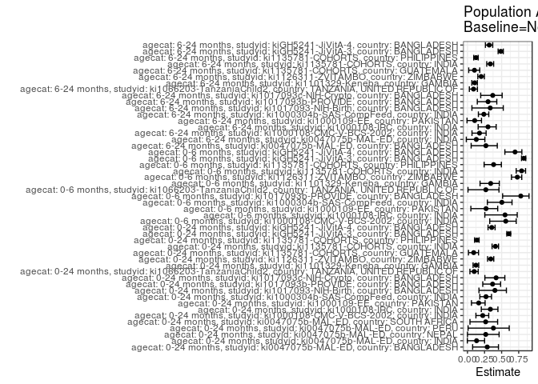

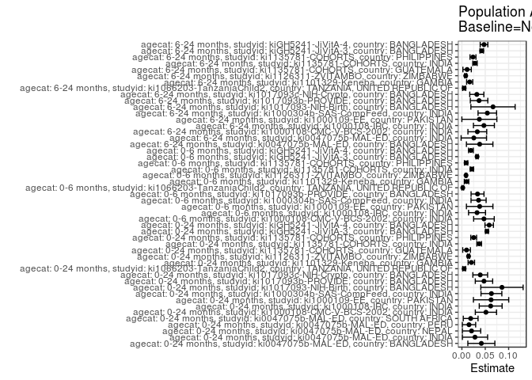

## Results Table

### Parameter: TSM

| agecat | studyid | country | intervention_level | baseline_level | estimate | ci_lower | ci_upper |
| --- | --- | --- | --- | --- | --- | --- | --- |
| 0-24 months | ki0047075b-MAL-ED | BANGLADESH | Normal or high birthweight | NA | 0.1023165 | 0.0603446 | 0.1442885 |
| 0-24 months | ki0047075b-MAL-ED | BANGLADESH | Low birth weight | NA | 0.2753868 | 0.1482248 | 0.4025487 |
| 0-24 months | ki0047075b-MAL-ED | INDIA | Normal or high birthweight | NA | 0.1818602 | 0.1290717 | 0.2346487 |
| 0-24 months | ki0047075b-MAL-ED | INDIA | Low birth weight | NA | 0.3685779 | 0.2050022 | 0.5321535 |
| 0-24 months | ki0047075b-MAL-ED | NEPAL | Normal or high birthweight | NA | 0.0566038 | 0.0254304 | 0.0877772 |
| 0-24 months | ki0047075b-MAL-ED | NEPAL | Low birth weight | NA | 0.2857143 | 0.0920835 | 0.4793451 |
| 0-24 months | ki0047075b-MAL-ED | PERU | Normal or high birthweight | NA | 0.0249110 | 0.0066578 | 0.0431643 |
| 0-24 months | ki0047075b-MAL-ED | PERU | Low birth weight | NA | 0.2777778 | 0.0705140 | 0.4850416 |
| 0-24 months | ki0047075b-MAL-ED | SOUTH AFRICA | Normal or high birthweight | NA | 0.0517241 | 0.0261936 | 0.0772547 |
| 0-24 months | ki0047075b-MAL-ED | SOUTH AFRICA | Low birth weight | NA | 0.3181818 | 0.1232396 | 0.5131240 |
| 0-24 months | ki1000108-CMC-V-BCS-2002 | INDIA | Normal or high birthweight | NA | 0.1791139 | 0.1376624 | 0.2205654 |
| 0-24 months | ki1000108-CMC-V-BCS-2002 | INDIA | Low birth weight | NA | 0.6309043 | 0.4819408 | 0.7798678 |
| 0-24 months | ki1000108-IRC | INDIA | Normal or high birthweight | NA | 0.1222233 | 0.0871363 | 0.1573103 |
| 0-24 months | ki1000108-IRC | INDIA | Low birth weight | NA | 0.4936197 | 0.3729190 | 0.6143204 |
| 0-24 months | ki1000109-EE | PAKISTAN | Normal or high birthweight | NA | 0.3175343 | 0.2585177 | 0.3765509 |
| 0-24 months | ki1000109-EE | PAKISTAN | Low birth weight | NA | 0.4982956 | 0.4134350 | 0.5831563 |
| 0-24 months | ki1000304b-SAS-CompFeed | INDIA | Normal or high birthweight | NA | 0.1696981 | 0.1335411 | 0.2058550 |
| 0-24 months | ki1000304b-SAS-CompFeed | INDIA | Low birth weight | NA | 0.4317806 | 0.3674003 | 0.4961609 |
| 0-24 months | ki1017093-NIH-Birth | BANGLADESH | Normal or high birthweight | NA | 0.1276201 | 0.0720799 | 0.1831604 |
| 0-24 months | ki1017093-NIH-Birth | BANGLADESH | Low birth weight | NA | 0.3618210 | 0.2556908 | 0.4679512 |
| 0-24 months | ki1017093b-PROVIDE | BANGLADESH | Normal or high birthweight | NA | 0.0813071 | 0.0578406 | 0.1047737 |
| 0-24 months | ki1017093b-PROVIDE | BANGLADESH | Low birth weight | NA | 0.2950253 | 0.2248496 | 0.3652011 |
| 0-24 months | ki1017093c-NIH-Crypto | BANGLADESH | Normal or high birthweight | NA | 0.0544204 | 0.0358898 | 0.0729509 |
| 0-24 months | ki1017093c-NIH-Crypto | BANGLADESH | Low birth weight | NA | 0.2329702 | 0.1708794 | 0.2950610 |
| 0-24 months | ki1066203-TanzaniaChild2 | TANZANIA, UNITED REPUBLIC OF | Normal or high birthweight | NA | 0.0440989 | 0.0356842 | 0.0525136 |
| 0-24 months | ki1066203-TanzaniaChild2 | TANZANIA, UNITED REPUBLIC OF | Low birth weight | NA | 0.1967729 | 0.1149900 | 0.2785558 |
| 0-24 months | ki1101329-Keneba | GAMBIA | Normal or high birthweight | NA | 0.1425895 | 0.1269309 | 0.1582482 |
| 0-24 months | ki1101329-Keneba | GAMBIA | Low birth weight | NA | 0.3590820 | 0.2909613 | 0.4272027 |
| 0-24 months | ki1126311-ZVITAMBO | ZIMBABWE | Normal or high birthweight | NA | 0.0275528 | 0.0246290 | 0.0304766 |
| 0-24 months | ki1126311-ZVITAMBO | ZIMBABWE | Low birth weight | NA | 0.1384015 | 0.1223825 | 0.1544205 |

[output cut: 68 more lines]

### Parameter: E(Y)

| agecat | studyid | country | intervention_level | baseline_level | estimate | ci_lower | ci_upper |
| --- | --- | --- | --- | --- | --- | --- | --- |
| 0-24 months | ki0047075b-MAL-ED | BANGLADESH | NA | NA | 0.1439689 | 0.1009650 | 0.1869727 |
| 0-24 months | ki0047075b-MAL-ED | INDIA | NA | NA | 0.2098765 | 0.1585703 | 0.2611827 |
| 0-24 months | ki0047075b-MAL-ED | NEPAL | NA | NA | 0.0772532 | 0.0428971 | 0.1116093 |
| 0-24 months | ki0047075b-MAL-ED | PERU | NA | NA | 0.0401338 | 0.0178494 | 0.0624181 |
| 0-24 months | ki0047075b-MAL-ED | SOUTH AFRICA | NA | NA | 0.0705128 | 0.0420601 | 0.0989655 |
| 0-24 months | ki1000108-CMC-V-BCS-2002 | INDIA | NA | NA | 0.2305630 | 0.1877616 | 0.2733644 |
| 0-24 months | ki1000108-IRC | INDIA | NA | NA | 0.1838235 | 0.1461927 | 0.2214543 |
| 0-24 months | ki1000109-EE | PAKISTAN | NA | NA | 0.3799472 | 0.3310169 | 0.4288776 |
| 0-24 months | ki1000304b-SAS-CompFeed | INDIA | NA | NA | 0.2328676 | 0.1923832 | 0.2733520 |
| 0-24 months | ki1017093-NIH-Birth | BANGLADESH | NA | NA | 0.2133333 | 0.1596859 | 0.2669808 |
| 0-24 months | ki1017093b-PROVIDE | BANGLADESH | NA | NA | 0.1285714 | 0.1037574 | 0.1533855 |
| 0-24 months | ki1017093c-NIH-Crypto | BANGLADESH | NA | NA | 0.0936675 | 0.0729118 | 0.1144233 |
| 0-24 months | ki1066203-TanzaniaChild2 | TANZANIA, UNITED REPUBLIC OF | NA | NA | 0.0489245 | 0.0402400 | 0.0576090 |
| 0-24 months | ki1101329-Keneba | GAMBIA | NA | NA | 0.1628126 | 0.1470895 | 0.1785358 |
| 0-24 months | ki1126311-ZVITAMBO | ZIMBABWE | NA | NA | 0.0418287 | 0.0384992 | 0.0451581 |
| 0-24 months | ki1135781-COHORTS | GUATEMALA | NA | NA | 0.1097955 | 0.0896809 | 0.1299101 |
| 0-24 months | ki1135781-COHORTS | INDIA | NA | NA | 0.0904114 | 0.0835737 | 0.0972490 |
| 0-24 months | ki1135781-COHORTS | PHILIPPINES | NA | NA | 0.1832722 | 0.1694278 | 0.1971167 |
| 0-24 months | kiGH5241-JiVitA-3 | BANGLADESH | NA | NA | 0.0886038 | 0.0847199 | 0.0924878 |
| 0-24 months | kiGH5241-JiVitA-4 | BANGLADESH | NA | NA | 0.1645963 | 0.1519758 | 0.1772167 |
| 0-6 months | ki1000108-CMC-V-BCS-2002 | INDIA | NA | NA | 0.0842391 | 0.0558231 | 0.1126551 |
| 0-6 months | ki1000108-IRC | INDIA | NA | NA | 0.0589681 | 0.0360543 | 0.0818818 |
| 0-6 months | ki1000109-EE | PAKISTAN | NA | NA | 0.1398417 | 0.1048786 | 0.1748048 |
| 0-6 months | ki1000304b-SAS-CompFeed | INDIA | NA | NA | 0.0709030 | 0.0481799 | 0.0936261 |
| 0-6 months | ki1017093b-PROVIDE | BANGLADESH | NA | NA | 0.0428571 | 0.0278427 | 0.0578716 |
| 0-6 months | ki1066203-TanzaniaChild2 | TANZANIA, UNITED REPUBLIC OF | NA | NA | 0.0071700 | 0.0037732 | 0.0105668 |
| 0-6 months | ki1101329-Keneba | GAMBIA | NA | NA | 0.0292909 | 0.0217971 | 0.0367846 |
| 0-6 months | ki1126311-ZVITAMBO | ZIMBABWE | NA | NA | 0.0121041 | 0.0102794 | 0.0139288 |
| 0-6 months | ki1135781-COHORTS | INDIA | NA | NA | 0.0269983 | 0.0230857 | 0.0309109 |
| 0-6 months | ki1135781-COHORTS | PHILIPPINES | NA | NA | 0.0236667 | 0.0182263 | 0.0291070 |
| 0-6 months | kiGH5241-JiVitA-3 | BANGLADESH | NA | NA | 0.0393827 | 0.0368929 | 0.0418726 |
| 0-6 months | kiGH5241-JiVitA-4 | BANGLADESH | NA | NA | 0.0277653 | 0.0218336 | 0.0336971 |
| 6-24 months | ki0047075b-MAL-ED | BANGLADESH | NA | NA | 0.1410256 | 0.0963358 | 0.1857155 |
| 6-24 months | ki0047075b-MAL-ED | INDIA | NA | NA | 0.1973684 | 0.1455920 | 0.2491449 |
| 6-24 months | ki1000108-CMC-V-BCS-2002 | INDIA | NA | NA | 0.1876676 | 0.1479906 | 0.2273445 |
| 6-24 months | ki1000108-IRC | INDIA | NA | NA | 0.1568627 | 0.1215314 | 0.1921941 |
| 6-24 months | ki1000109-EE | PAKISTAN | NA | NA | 0.3538874 | 0.3052956 | 0.4024792 |
| 6-24 months | ki1000304b-SAS-CompFeed | INDIA | NA | NA | 0.2269761 | 0.1910133 | 0.2629388 |
| 6-24 months | ki1017093-NIH-Birth | BANGLADESH | NA | NA | 0.2000000 | 0.1414022 | 0.2585978 |
| 6-24 months | ki1017093b-PROVIDE | BANGLADESH | NA | NA | 0.1221498 | 0.0962275 | 0.1480722 |
| 6-24 months | ki1017093c-NIH-Crypto | BANGLADESH | NA | NA | 0.0863014 | 0.0659171 | 0.1066856 |
| 6-24 months | ki1066203-TanzaniaChild2 | TANZANIA, UNITED REPUBLIC OF | NA | NA | 0.0555834 | 0.0455321 | 0.0656347 |
| 6-24 months | ki1101329-Keneba | GAMBIA | NA | NA | 0.1584110 | 0.1425588 | 0.1742632 |
| 6-24 months | ki1126311-ZVITAMBO | ZIMBABWE | NA | NA | 0.0407206 | 0.0369682 | 0.0444730 |
| 6-24 months | ki1135781-COHORTS | GUATEMALA | NA | NA | 0.1090909 | 0.0878048 | 0.1303770 |
| 6-24 months | ki1135781-COHORTS | INDIA | NA | NA | 0.0837039 | 0.0768626 | 0.0905453 |
| 6-24 months | ki1135781-COHORTS | PHILIPPINES | NA | NA | 0.1902351 | 0.1756031 | 0.2048671 |
| 6-24 months | kiGH5241-JiVitA-3 | BANGLADESH | NA | NA | 0.0869919 | 0.0823156 | 0.0916682 |
| 6-24 months | kiGH5241-JiVitA-4 | BANGLADESH | NA | NA | 0.1486997 | 0.1368826 | 0.1605168 |

### Parameter: RR

| agecat | studyid | country | intervention_level | baseline_level | estimate | ci_lower | ci_upper |
| --- | --- | --- | --- | --- | --- | --- | --- |
| 0-24 months | ki0047075b-MAL-ED | BANGLADESH | Normal or high birthweight | Normal or high birthweight | 1.000000 | 1.000000 | 1.000000 |
| 0-24 months | ki0047075b-MAL-ED | BANGLADESH | Low birth weight | Normal or high birthweight | 2.691518 | 1.447121 | 5.005989 |
| 0-24 months | ki0047075b-MAL-ED | INDIA | Normal or high birthweight | Normal or high birthweight | 1.000000 | 1.000000 | 1.000000 |
| 0-24 months | ki0047075b-MAL-ED | INDIA | Low birth weight | Normal or high birthweight | 2.026710 | 1.191253 | 3.448094 |
| 0-24 months | ki0047075b-MAL-ED | NEPAL | Normal or high birthweight | Normal or high birthweight | 1.000000 | 1.000000 | 1.000000 |
| 0-24 months | ki0047075b-MAL-ED | NEPAL | Low birth weight | Normal or high birthweight | 5.047619 | 2.107816 | 12.087613 |
| 0-24 months | ki0047075b-MAL-ED | PERU | Normal or high birthweight | Normal or high birthweight | 1.000000 | 1.000000 | 1.000000 |
| 0-24 months | ki0047075b-MAL-ED | PERU | Low birth weight | Normal or high birthweight | 11.150794 | 3.918607 | 31.730715 |
| 0-24 months | ki0047075b-MAL-ED | SOUTH AFRICA | Normal or high birthweight | Normal or high birthweight | 1.000000 | 1.000000 | 1.000000 |
| 0-24 months | ki0047075b-MAL-ED | SOUTH AFRICA | Low birth weight | Normal or high birthweight | 6.151515 | 2.800873 | 13.510481 |
| 0-24 months | ki1000108-CMC-V-BCS-2002 | INDIA | Normal or high birthweight | Normal or high birthweight | 1.000000 | 1.000000 | 1.000000 |
| 0-24 months | ki1000108-CMC-V-BCS-2002 | INDIA | Low birth weight | Normal or high birthweight | 3.522364 | 2.529677 | 4.904596 |
| 0-24 months | ki1000108-IRC | INDIA | Normal or high birthweight | Normal or high birthweight | 1.000000 | 1.000000 | 1.000000 |
| 0-24 months | ki1000108-IRC | INDIA | Low birth weight | Normal or high birthweight | 4.038670 | 2.774066 | 5.879766 |
| 0-24 months | ki1000109-EE | PAKISTAN | Normal or high birthweight | Normal or high birthweight | 1.000000 | 1.000000 | 1.000000 |
| 0-24 months | ki1000109-EE | PAKISTAN | Low birth weight | Normal or high birthweight | 1.569266 | 1.218418 | 2.021141 |
| 0-24 months | ki1000304b-SAS-CompFeed | INDIA | Normal or high birthweight | Normal or high birthweight | 1.000000 | 1.000000 | 1.000000 |
| 0-24 months | ki1000304b-SAS-CompFeed | INDIA | Low birth weight | Normal or high birthweight | 2.544405 | 2.089455 | 3.098415 |
| 0-24 months | ki1017093-NIH-Birth | BANGLADESH | Normal or high birthweight | Normal or high birthweight | 1.000000 | 1.000000 | 1.000000 |
| 0-24 months | ki1017093-NIH-Birth | BANGLADESH | Low birth weight | Normal or high birthweight | 2.835140 | 1.678372 | 4.789176 |
| 0-24 months | ki1017093b-PROVIDE | BANGLADESH | Normal or high birthweight | Normal or high birthweight | 1.000000 | 1.000000 | 1.000000 |
| 0-24 months | ki1017093b-PROVIDE | BANGLADESH | Low birth weight | Normal or high birthweight | 3.628529 | 2.492921 | 5.281444 |
| 0-24 months | ki1017093c-NIH-Crypto | BANGLADESH | Normal or high birthweight | Normal or high birthweight | 1.000000 | 1.000000 | 1.000000 |
| 0-24 months | ki1017093c-NIH-Crypto | BANGLADESH | Low birth weight | Normal or high birthweight | 4.280938 | 2.776957 | 6.599466 |
| 0-24 months | ki1066203-TanzaniaChild2 | TANZANIA, UNITED REPUBLIC OF | Normal or high birthweight | Normal or high birthweight | 1.000000 | 1.000000 | 1.000000 |
| 0-24 months | ki1066203-TanzaniaChild2 | TANZANIA, UNITED REPUBLIC OF | Low birth weight | Normal or high birthweight | 4.462079 | 2.824613 | 7.048807 |
| 0-24 months | ki1101329-Keneba | GAMBIA | Normal or high birthweight | Normal or high birthweight | 1.000000 | 1.000000 | 1.000000 |
| 0-24 months | ki1101329-Keneba | GAMBIA | Low birth weight | Normal or high birthweight | 2.518291 | 2.024186 | 3.133008 |
| 0-24 months | ki1126311-ZVITAMBO | ZIMBABWE | Normal or high birthweight | Normal or high birthweight | 1.000000 | 1.000000 | 1.000000 |
| 0-24 months | ki1126311-ZVITAMBO | ZIMBABWE | Low birth weight | Normal or high birthweight | 5.023136 | 4.293621 | 5.876602 |

[output cut: 68 more lines]

### Parameter: PAR

| agecat | studyid | country | intervention_level | baseline_level | estimate | ci_lower | ci_upper |
| --- | --- | --- | --- | --- | --- | --- | --- |
| 0-24 months | ki0047075b-MAL-ED | BANGLADESH | Normal or high birthweight | NA | 0.0416524 | 0.0127617 | 0.0705431 |
| 0-24 months | ki0047075b-MAL-ED | INDIA | Normal or high birthweight | NA | 0.0280163 | 0.0010262 | 0.0550064 |
| 0-24 months | ki0047075b-MAL-ED | NEPAL | Normal or high birthweight | NA | 0.0206494 | 0.0010604 | 0.0402385 |
| 0-24 months | ki0047075b-MAL-ED | PERU | Normal or high birthweight | NA | 0.0152227 | 0.0009565 | 0.0294890 |
| 0-24 months | ki0047075b-MAL-ED | SOUTH AFRICA | Normal or high birthweight | NA | 0.0187887 | 0.0029877 | 0.0345896 |
| 0-24 months | ki1000108-CMC-V-BCS-2002 | INDIA | Normal or high birthweight | NA | 0.0514491 | 0.0287441 | 0.0741541 |
| 0-24 months | ki1000108-IRC | INDIA | Normal or high birthweight | NA | 0.0616002 | 0.0371592 | 0.0860412 |
| 0-24 months | ki1000109-EE | PAKISTAN | Normal or high birthweight | NA | 0.0624129 | 0.0246644 | 0.1001615 |
| 0-24 months | ki1000304b-SAS-CompFeed | INDIA | Normal or high birthweight | NA | 0.0631695 | 0.0408691 | 0.0854699 |
| 0-24 months | ki1017093-NIH-Birth | BANGLADESH | Normal or high birthweight | NA | 0.0857132 | 0.0404690 | 0.1309574 |
| 0-24 months | ki1017093b-PROVIDE | BANGLADESH | Normal or high birthweight | NA | 0.0472643 | 0.0286887 | 0.0658399 |
| 0-24 months | ki1017093c-NIH-Crypto | BANGLADESH | Normal or high birthweight | NA | 0.0392472 | 0.0234720 | 0.0550224 |
| 0-24 months | ki1066203-TanzaniaChild2 | TANZANIA, UNITED REPUBLIC OF | Normal or high birthweight | NA | 0.0048256 | 0.0017451 | 0.0079061 |
| 0-24 months | ki1101329-Keneba | GAMBIA | Normal or high birthweight | NA | 0.0202231 | 0.0133483 | 0.0270979 |
| 0-24 months | ki1126311-ZVITAMBO | ZIMBABWE | Normal or high birthweight | NA | 0.0142758 | 0.0120930 | 0.0164587 |
| 0-24 months | ki1135781-COHORTS | GUATEMALA | Normal or high birthweight | NA | 0.0100171 | 0.0017672 | 0.0182670 |
| 0-24 months | ki1135781-COHORTS | INDIA | Normal or high birthweight | NA | 0.0369864 | 0.0319944 | 0.0419784 |
| 0-24 months | ki1135781-COHORTS | PHILIPPINES | Normal or high birthweight | NA | 0.0252661 | 0.0190401 | 0.0314921 |
| 0-24 months | kiGH5241-JiVitA-3 | BANGLADESH | Normal or high birthweight | NA | 0.0536183 | 0.0503815 | 0.0568551 |
| 0-24 months | kiGH5241-JiVitA-4 | BANGLADESH | Normal or high birthweight | NA | 0.0583913 | 0.0493517 | 0.0674309 |
| 0-6 months | ki1000108-CMC-V-BCS-2002 | INDIA | Normal or high birthweight | NA | 0.0472156 | 0.0251965 | 0.0692346 |
| 0-6 months | ki1000108-IRC | INDIA | Normal or high birthweight | NA | 0.0324194 | 0.0142656 | 0.0505732 |
| 0-6 months | ki1000109-EE | PAKISTAN | Normal or high birthweight | NA | 0.0380619 | 0.0097326 | 0.0663911 |
| 0-6 months | ki1000304b-SAS-CompFeed | INDIA | Normal or high birthweight | NA | 0.0357067 | 0.0195604 | 0.0518531 |
| 0-6 months | ki1017093b-PROVIDE | BANGLADESH | Normal or high birthweight | NA | 0.0334586 | 0.0196592 | 0.0472581 |
| 0-6 months | ki1066203-TanzaniaChild2 | TANZANIA, UNITED REPUBLIC OF | Normal or high birthweight | NA | 0.0019275 | 0.0000868 | 0.0037682 |
| 0-6 months | ki1101329-Keneba | GAMBIA | Normal or high birthweight | NA | 0.0099525 | 0.0051660 | 0.0147390 |
| 0-6 months | ki1126311-ZVITAMBO | ZIMBABWE | Normal or high birthweight | NA | 0.0088324 | 0.0072303 | 0.0104346 |
| 0-6 months | ki1135781-COHORTS | INDIA | Normal or high birthweight | NA | 0.0214057 | 0.0178252 | 0.0249861 |
| 0-6 months | ki1135781-COHORTS | PHILIPPINES | Normal or high birthweight | NA | 0.0090579 | 0.0054552 | 0.0126606 |
| 0-6 months | kiGH5241-JiVitA-3 | BANGLADESH | Normal or high birthweight | NA | 0.0324961 | 0.0301015 | 0.0348907 |
| 0-6 months | kiGH5241-JiVitA-4 | BANGLADESH | Normal or high birthweight | NA | 0.0193333 | 0.0142120 | 0.0244545 |
| 6-24 months | ki0047075b-MAL-ED | BANGLADESH | Normal or high birthweight | NA | 0.0380459 | 0.0097332 | 0.0663587 |
| 6-24 months | ki0047075b-MAL-ED | INDIA | Normal or high birthweight | NA | 0.0255367 | -0.0016546 | 0.0527280 |
| 6-24 months | ki1000108-CMC-V-BCS-2002 | INDIA | Normal or high birthweight | NA | 0.0330208 | 0.0129473 | 0.0530942 |
| 6-24 months | ki1000108-IRC | INDIA | Normal or high birthweight | NA | 0.0471218 | 0.0247319 | 0.0695117 |
| 6-24 months | ki1000109-EE | PAKISTAN | Normal or high birthweight | NA | 0.0373663 | -0.0000462 | 0.0747787 |
| 6-24 months | ki1000304b-SAS-CompFeed | INDIA | Normal or high birthweight | NA | 0.0544007 | 0.0345541 | 0.0742474 |
| 6-24 months | ki1017093-NIH-Birth | BANGLADESH | Normal or high birthweight | NA | 0.0665769 | 0.0192521 | 0.1139016 |
| 6-24 months | ki1017093b-PROVIDE | BANGLADESH | Normal or high birthweight | NA | 0.0367631 | 0.0180824 | 0.0554438 |
| 6-24 months | ki1017093c-NIH-Crypto | BANGLADESH | Normal or high birthweight | NA | 0.0319173 | 0.0168480 | 0.0469865 |
| 6-24 months | ki1066203-TanzaniaChild2 | TANZANIA, UNITED REPUBLIC OF | Normal or high birthweight | NA | 0.0049225 | 0.0015373 | 0.0083076 |
| 6-24 months | ki1101329-Keneba | GAMBIA | Normal or high birthweight | NA | 0.0166631 | 0.0101454 | 0.0231807 |
| 6-24 months | ki1126311-ZVITAMBO | ZIMBABWE | Normal or high birthweight | NA | 0.0081767 | 0.0060924 | 0.0102610 |
| 6-24 months | ki1135781-COHORTS | GUATEMALA | Normal or high birthweight | NA | 0.0111803 | 0.0021914 | 0.0201692 |
| 6-24 months | ki1135781-COHORTS | INDIA | Normal or high birthweight | NA | 0.0280065 | 0.0232968 | 0.0327162 |
| 6-24 months | ki1135781-COHORTS | PHILIPPINES | Normal or high birthweight | NA | 0.0237486 | 0.0174312 | 0.0300660 |
| 6-24 months | kiGH5241-JiVitA-3 | BANGLADESH | Normal or high birthweight | NA | 0.0424461 | 0.0386115 | 0.0462807 |
| 6-24 months | kiGH5241-JiVitA-4 | BANGLADESH | Normal or high birthweight | NA | 0.0473538 | 0.0391753 | 0.0555323 |

### Parameter: PAF

| agecat | studyid | country | intervention_level | baseline_level | estimate | ci_lower | ci_upper |
| --- | --- | --- | --- | --- | --- | --- | --- |
| 0-24 months | ki0047075b-MAL-ED | BANGLADESH | Normal or high birthweight | NA | 0.2893151 | 0.0757727 | 0.4535186 |
| 0-24 months | ki0047075b-MAL-ED | INDIA | Normal or high birthweight | NA | 0.1334896 | -0.0020713 | 0.2507118 |
| 0-24 months | ki0047075b-MAL-ED | NEPAL | Normal or high birthweight | NA | 0.2672956 | 0.0000866 | 0.4630978 |
| 0-24 months | ki0047075b-MAL-ED | PERU | Normal or high birthweight | NA | 0.3793001 | 0.0090832 | 0.6112001 |
| 0-24 months | ki0047075b-MAL-ED | SOUTH AFRICA | Normal or high birthweight | NA | 0.2664577 | 0.0367304 | 0.4413980 |
| 0-24 months | ki1000108-CMC-V-BCS-2002 | INDIA | Normal or high birthweight | NA | 0.2231455 | 0.1236056 | 0.3113798 |
| 0-24 months | ki1000108-IRC | INDIA | Normal or high birthweight | NA | 0.3351051 | 0.2024723 | 0.4456804 |
| 0-24 months | ki1000109-EE | PAKISTAN | Normal or high birthweight | NA | 0.1642674 | 0.0584009 | 0.2582310 |
| 0-24 months | ki1000304b-SAS-CompFeed | INDIA | Normal or high birthweight | NA | 0.2712681 | 0.1809602 | 0.3516185 |
| 0-24 months | ki1017093-NIH-Birth | BANGLADESH | Normal or high birthweight | NA | 0.4017806 | 0.1680066 | 0.5698686 |
| 0-24 months | ki1017093b-PROVIDE | BANGLADESH | Normal or high birthweight | NA | 0.3676111 | 0.2238184 | 0.4847653 |
| 0-24 months | ki1017093c-NIH-Crypto | BANGLADESH | Normal or high birthweight | NA | 0.4190052 | 0.2547495 | 0.5470583 |
| 0-24 months | ki1066203-TanzaniaChild2 | TANZANIA, UNITED REPUBLIC OF | Normal or high birthweight | NA | 0.0986332 | 0.0357955 | 0.1573757 |
| 0-24 months | ki1101329-Keneba | GAMBIA | Normal or high birthweight | NA | 0.1242110 | 0.0820461 | 0.1644390 |
| 0-24 months | ki1126311-ZVITAMBO | ZIMBABWE | Normal or high birthweight | NA | 0.3412934 | 0.2945769 | 0.3849161 |
| 0-24 months | ki1135781-COHORTS | GUATEMALA | Normal or high birthweight | NA | 0.0912342 | 0.0144709 | 0.1620184 |
| 0-24 months | ki1135781-COHORTS | INDIA | Normal or high birthweight | NA | 0.4090901 | 0.3599260 | 0.4544780 |
| 0-24 months | ki1135781-COHORTS | PHILIPPINES | Normal or high birthweight | NA | 0.1378611 | 0.1041670 | 0.1702879 |
| 0-24 months | kiGH5241-JiVitA-3 | BANGLADESH | Normal or high birthweight | NA | 0.6051468 | 0.5756534 | 0.6325903 |
| 0-24 months | kiGH5241-JiVitA-4 | BANGLADESH | Normal or high birthweight | NA | 0.3547548 | 0.3011110 | 0.4042811 |
| 0-6 months | ki1000108-CMC-V-BCS-2002 | INDIA | Normal or high birthweight | NA | 0.5604944 | 0.3257171 | 0.7135250 |
| 0-6 months | ki1000108-IRC | INDIA | Normal or high birthweight | NA | 0.5497788 | 0.2539172 | 0.7283154 |
| 0-6 months | ki1000109-EE | PAKISTAN | Normal or high birthweight | NA | 0.2721782 | 0.0496597 | 0.4425948 |
| 0-6 months | ki1000304b-SAS-CompFeed | INDIA | Normal or high birthweight | NA | 0.5035997 | 0.2915371 | 0.6521860 |
| 0-6 months | ki1017093b-PROVIDE | BANGLADESH | Normal or high birthweight | NA | 0.7807018 | 0.5147381 | 0.9008953 |
| 0-6 months | ki1066203-TanzaniaChild2 | TANZANIA, UNITED REPUBLIC OF | Normal or high birthweight | NA | 0.2688305 | 0.0076893 | 0.4612485 |
| 0-6 months | ki1101329-Keneba | GAMBIA | Normal or high birthweight | NA | 0.3397818 | 0.1839661 | 0.4658456 |
| 0-6 months | ki1126311-ZVITAMBO | ZIMBABWE | Normal or high birthweight | NA | 0.7297083 | 0.6443464 | 0.7945822 |
| 0-6 months | ki1135781-COHORTS | INDIA | Normal or high birthweight | NA | 0.7928515 | 0.7130542 | 0.8504578 |
| 0-6 months | ki1135781-COHORTS | PHILIPPINES | Normal or high birthweight | NA | 0.3827286 | 0.2437078 | 0.4961948 |
| 0-6 months | kiGH5241-JiVitA-3 | BANGLADESH | Normal or high birthweight | NA | 0.8251352 | 0.7912250 | 0.8535375 |
| 0-6 months | kiGH5241-JiVitA-4 | BANGLADESH | Normal or high birthweight | NA | 0.6963101 | 0.5474282 | 0.7962145 |
| 6-24 months | ki0047075b-MAL-ED | BANGLADESH | Normal or high birthweight | NA | 0.2697802 | 0.0539139 | 0.4363929 |
| 6-24 months | ki0047075b-MAL-ED | INDIA | Normal or high birthweight | NA | 0.1293860 | -0.0170113 | 0.2547096 |
| 6-24 months | ki1000108-CMC-V-BCS-2002 | INDIA | Normal or high birthweight | NA | 0.1759535 | 0.0662151 | 0.2727954 |
| 6-24 months | ki1000108-IRC | INDIA | Normal or high birthweight | NA | 0.3004015 | 0.1562895 | 0.4198981 |
| 6-24 months | ki1000109-EE | PAKISTAN | Normal or high birthweight | NA | 0.1055880 | -0.0066372 | 0.2053018 |
| 6-24 months | ki1000304b-SAS-CompFeed | INDIA | Normal or high birthweight | NA | 0.2396761 | 0.1598375 | 0.3119278 |
| 6-24 months | ki1017093-NIH-Birth | BANGLADESH | Normal or high birthweight | NA | 0.3328843 | 0.0650310 | 0.5240020 |
| 6-24 months | ki1017093b-PROVIDE | BANGLADESH | Normal or high birthweight | NA | 0.3009673 | 0.1440551 | 0.4291143 |
| 6-24 months | ki1017093c-NIH-Crypto | BANGLADESH | Normal or high birthweight | NA | 0.3698348 | 0.1938518 | 0.5074006 |
| 6-24 months | ki1066203-TanzaniaChild2 | TANZANIA, UNITED REPUBLIC OF | Normal or high birthweight | NA | 0.0885599 | 0.0275707 | 0.1457240 |
| 6-24 months | ki1101329-Keneba | GAMBIA | Normal or high birthweight | NA | 0.1051889 | 0.0639156 | 0.1446425 |
| 6-24 months | ki1126311-ZVITAMBO | ZIMBABWE | Normal or high birthweight | NA | 0.2008004 | 0.1512020 | 0.2475005 |
| 6-24 months | ki1135781-COHORTS | GUATEMALA | Normal or high birthweight | NA | 0.1024863 | 0.0182724 | 0.1794763 |
| 6-24 months | ki1135781-COHORTS | INDIA | Normal or high birthweight | NA | 0.3345900 | 0.2822244 | 0.3831352 |
| 6-24 months | ki1135781-COHORTS | PHILIPPINES | Normal or high birthweight | NA | 0.1248380 | 0.0917711 | 0.1567010 |
| 6-24 months | kiGH5241-JiVitA-3 | BANGLADESH | Normal or high birthweight | NA | 0.4879317 | 0.4485249 | 0.5245226 |
| 6-24 months | kiGH5241-JiVitA-4 | BANGLADESH | Normal or high birthweight | NA | 0.3184525 | 0.2629927 | 0.3697390 |